# Optimal Treatment Analysis

## Outcome Variable

**Outcome Variable:** ever_stunted

## Predictor Variables

**Intervention Variable:** birthwt

**Adjustment Set:**

- arm
- sex
- W_mage
- meducyrs
- feducyrs
- hhwealth_quart
- vagbrth
- W_nrooms
- brthmon
- W_parity
- impsan
- delta_W_mage
- delta_meducyrs
- delta_feducyrs
- delta_hhwealth_quart
- delta_vagbrth
- delta_W_nrooms
- delta_brthmon
- delta_W_parity
- delta_impsan

## Stratifying Variables

The analysis was stratified on these variable(s):

- agecat
- studyid
- country

## Data Summary

| agecat | studyid | country | birthwt | ever_stunted | n_cell | n |
| --- | --- | --- | --- | --- | --- | --- |
| 0-24 months (no birth st.) | ki0047075b-MAL-ED | BANGLADESH | Normal or high birthweight | 0 | 92 | 212 |
| 0-24 months (no birth st.) | ki0047075b-MAL-ED | BANGLADESH | Normal or high birthweight | 1 | 96 | 212 |
| 0-24 months (no birth st.) | ki0047075b-MAL-ED | BANGLADESH | Low birth weight | 0 | 9 | 212 |
| 0-24 months (no birth st.) | ki0047075b-MAL-ED | BANGLADESH | Low birth weight | 1 | 15 | 212 |
| 0-24 months (no birth st.) | ki0047075b-MAL-ED | BRAZIL | Normal or high birthweight | 0 | 176 | 208 |
| 0-24 months (no birth st.) | ki0047075b-MAL-ED | BRAZIL | Normal or high birthweight | 1 | 29 | 208 |
| 0-24 months (no birth st.) | ki0047075b-MAL-ED | BRAZIL | Low birth weight | 0 | 3 | 208 |
| 0-24 months (no birth st.) | ki0047075b-MAL-ED | BRAZIL | Low birth weight | 1 | 0 | 208 |
| 0-24 months (no birth st.) | ki0047075b-MAL-ED | INDIA | Normal or high birthweight | 0 | 87 | 205 |
| 0-24 months (no birth st.) | ki0047075b-MAL-ED | INDIA | Normal or high birthweight | 1 | 97 | 205 |
| 0-24 months (no birth st.) | ki0047075b-MAL-ED | INDIA | Low birth weight | 0 | 11 | 205 |
| 0-24 months (no birth st.) | ki0047075b-MAL-ED | INDIA | Low birth weight | 1 | 10 | 205 |
| 0-24 months (no birth st.) | ki0047075b-MAL-ED | NEPAL | Normal or high birthweight | 0 | 151 | 206 |
| 0-24 months (no birth st.) | ki0047075b-MAL-ED | NEPAL | Normal or high birthweight | 1 | 47 | 206 |
| 0-24 months (no birth st.) | ki0047075b-MAL-ED | NEPAL | Low birth weight | 0 | 5 | 206 |
| 0-24 months (no birth st.) | ki0047075b-MAL-ED | NEPAL | Low birth weight | 1 | 3 | 206 |
| 0-24 months (no birth st.) | ki0047075b-MAL-ED | PERU | Normal or high birthweight | 0 | 114 | 264 |
| 0-24 months (no birth st.) | ki0047075b-MAL-ED | PERU | Normal or high birthweight | 1 | 148 | 264 |
| 0-24 months (no birth st.) | ki0047075b-MAL-ED | PERU | Low birth weight | 0 | 0 | 264 |
| 0-24 months (no birth st.) | ki0047075b-MAL-ED | PERU | Low birth weight | 1 | 2 | 264 |
| 0-24 months (no birth st.) | ki0047075b-MAL-ED | SOUTH AFRICA | Normal or high birthweight | 0 | 140 | 280 |
| 0-24 months (no birth st.) | ki0047075b-MAL-ED | SOUTH AFRICA | Normal or high birthweight | 1 | 130 | 280 |
| 0-24 months (no birth st.) | ki0047075b-MAL-ED | SOUTH AFRICA | Low birth weight | 0 | 3 | 280 |
| 0-24 months (no birth st.) | ki0047075b-MAL-ED | SOUTH AFRICA | Low birth weight | 1 | 7 | 280 |
| 0-24 months (no birth st.) | ki0047075b-MAL-ED | TANZANIA, UNITED REPUBLIC OF | Normal or high birthweight | 0 | 27 | 116 |
| 0-24 months (no birth st.) | ki0047075b-MAL-ED | TANZANIA, UNITED REPUBLIC OF | Normal or high birthweight | 1 | 88 | 116 |
| 0-24 months (no birth st.) | ki0047075b-MAL-ED | TANZANIA, UNITED REPUBLIC OF | Low birth weight | 0 | 1 | 116 |
| 0-24 months (no birth st.) | ki0047075b-MAL-ED | TANZANIA, UNITED REPUBLIC OF | Low birth weight | 1 | 0 | 116 |
| 0-24 months (no birth st.) | ki1000108-CMC-V-BCS-2002 | INDIA | Normal or high birthweight | 0 | 27 | 296 |
| 0-24 months (no birth st.) | ki1000108-CMC-V-BCS-2002 | INDIA | Normal or high birthweight | 1 | 255 | 296 |

[output cut: 314 more lines]

The following strata were considered:

- agecat: 0-24 months (no birth st.), studyid: ki0047075b-MAL-ED, country: BANGLADESH
- agecat: 0-24 months (no birth st.), studyid: ki0047075b-MAL-ED, country: BRAZIL
- agecat: 0-24 months (no birth st.), studyid: ki0047075b-MAL-ED, country: INDIA
- agecat: 0-24 months (no birth st.), studyid: ki0047075b-MAL-ED, country: NEPAL
- agecat: 0-24 months (no birth st.), studyid: ki0047075b-MAL-ED, country: PERU
- agecat: 0-24 months (no birth st.), studyid: ki0047075b-MAL-ED, country: SOUTH AFRICA
- agecat: 0-24 months (no birth st.), studyid: ki0047075b-MAL-ED, country: TANZANIA, UNITED REPUBLIC OF
- agecat: 0-24 months (no birth st.), studyid: ki1000108-CMC-V-BCS-2002, country: INDIA
- agecat: 0-24 months (no birth st.), studyid: ki1000108-IRC, country: INDIA
- agecat: 0-24 months (no birth st.), studyid: ki1000109-EE, country: PAKISTAN
- agecat: 0-24 months (no birth st.), studyid: ki1000109-ResPak, country: PAKISTAN
- agecat: 0-24 months (no birth st.), studyid: ki1000304b-SAS-CompFeed, country: INDIA
- agecat: 0-24 months (no birth st.), studyid: ki1017093-NIH-Birth, country: BANGLADESH
- agecat: 0-24 months (no birth st.), studyid: ki1017093b-PROVIDE, country: BANGLADESH
- agecat: 0-24 months (no birth st.), studyid: ki1017093c-NIH-Crypto, country: BANGLADESH
- agecat: 0-24 months (no birth st.), studyid: ki1066203-TanzaniaChild2, country: TANZANIA, UNITED REPUBLIC OF
- agecat: 0-24 months (no birth st.), studyid: ki1101329-Keneba, country: GAMBIA
- agecat: 0-24 months (no birth st.), studyid: ki1114097-CMIN, country: BANGLADESH
- agecat: 0-24 months (no birth st.), studyid: ki1114097-CMIN, country: BRAZIL
- agecat: 0-24 months (no birth st.), studyid: ki1114097-CMIN, country: GUINEA-BISSAU
- agecat: 0-24 months (no birth st.), studyid: ki1114097-CMIN, country: PERU
- agecat: 0-24 months (no birth st.), studyid: ki1114097-CONTENT, country: PERU
- agecat: 0-24 months (no birth st.), studyid: ki1119695-PROBIT, country: BELARUS
- agecat: 0-24 months (no birth st.), studyid: ki1126311-ZVITAMBO, country: ZIMBABWE
- agecat: 0-24 months (no birth st.), studyid: ki1135781-COHORTS, country: GUATEMALA
- agecat: 0-24 months (no birth st.), studyid: ki1135781-COHORTS, country: INDIA
- agecat: 0-24 months (no birth st.), studyid: ki1135781-COHORTS, country: PHILIPPINES
- agecat: 0-24 months (no birth st.), studyid: kiGH5241-JiVitA-3, country: BANGLADESH
- agecat: 0-24 months (no birth st.), studyid: kiGH5241-JiVitA-4, country: BANGLADESH
- agecat: 0-6 months (no birth st.), studyid: ki0047075b-MAL-ED, country: BANGLADESH
- agecat: 0-6 months (no birth st.), studyid: ki0047075b-MAL-ED, country: BRAZIL
- agecat: 0-6 months (no birth st.), studyid: ki0047075b-MAL-ED, country: INDIA
- agecat: 0-6 months (no birth st.), studyid: ki0047075b-MAL-ED, country: NEPAL
- agecat: 0-6 months (no birth st.), studyid: ki0047075b-MAL-ED, country: PERU
- agecat: 0-6 months (no birth st.), studyid: ki0047075b-MAL-ED, country: SOUTH AFRICA
- agecat: 0-6 months (no birth st.), studyid: ki0047075b-MAL-ED, country: TANZANIA, UNITED REPUBLIC OF
- agecat: 0-6 months (no birth st.), studyid: ki1000108-CMC-V-BCS-2002, country: INDIA
- agecat: 0-6 months (no birth st.), studyid: ki1000108-IRC, country: INDIA
- agecat: 0-6 months (no birth st.), studyid: ki1000109-EE, country: PAKISTAN
- agecat: 0-6 months (no birth st.), studyid: ki1000109-ResPak, country: PAKISTAN
- agecat: 0-6 months (no birth st.), studyid: ki1000304b-SAS-CompFeed, country: INDIA
- agecat: 0-6 months (no birth st.), studyid: ki1017093-NIH-Birth, country: BANGLADESH
- agecat: 0-6 months (no birth st.), studyid: ki1017093b-PROVIDE, country: BANGLADESH
- agecat: 0-6 months (no birth st.), studyid: ki1017093c-NIH-Crypto, country: BANGLADESH
- agecat: 0-6 months (no birth st.), studyid: ki1066203-TanzaniaChild2, country: TANZANIA, UNITED REPUBLIC OF
- agecat: 0-6 months (no birth st.), studyid: ki1101329-Keneba, country: GAMBIA
- agecat: 0-6 months (no birth st.), studyid: ki1114097-CMIN, country: BANGLADESH
- agecat: 0-6 months (no birth st.), studyid: ki1114097-CMIN, country: BRAZIL
- agecat: 0-6 months (no birth st.), studyid: ki1114097-CMIN, country: GUINEA-BISSAU
- agecat: 0-6 months (no birth st.), studyid: ki1114097-CMIN, country: PERU
- agecat: 0-6 months (no birth st.), studyid: ki1114097-CONTENT, country: PERU
- agecat: 0-6 months (no birth st.), studyid: ki1119695-PROBIT, country: BELARUS
- agecat: 0-6 months (no birth st.), studyid: ki1126311-ZVITAMBO, country: ZIMBABWE
- agecat: 0-6 months (no birth st.), studyid: ki1135781-COHORTS, country: GUATEMALA
- agecat: 0-6 months (no birth st.), studyid: ki1135781-COHORTS, country: INDIA
- agecat: 0-6 months (no birth st.), studyid: ki1135781-COHORTS, country: PHILIPPINES
- agecat: 0-6 months (no birth st.), studyid: kiGH5241-JiVitA-3, country: BANGLADESH
- agecat: 0-6 months (no birth st.), studyid: kiGH5241-JiVitA-4, country: BANGLADESH
- agecat: 6-24 months, studyid: ki0047075b-MAL-ED, country: BANGLADESH
- agecat: 6-24 months, studyid: ki0047075b-MAL-ED, country: BRAZIL
- agecat: 6-24 months, studyid: ki0047075b-MAL-ED, country: INDIA
- agecat: 6-24 months, studyid: ki0047075b-MAL-ED, country: NEPAL
- agecat: 6-24 months, studyid: ki0047075b-MAL-ED, country: PERU
- agecat: 6-24 months, studyid: ki0047075b-MAL-ED, country: SOUTH AFRICA
- agecat: 6-24 months, studyid: ki0047075b-MAL-ED, country: TANZANIA, UNITED REPUBLIC OF
- agecat: 6-24 months, studyid: ki1000108-CMC-V-BCS-2002, country: INDIA
- agecat: 6-24 months, studyid: ki1000108-IRC, country: INDIA
- agecat: 6-24 months, studyid: ki1000109-EE, country: PAKISTAN
- agecat: 6-24 months, studyid: ki1000109-ResPak, country: PAKISTAN
- agecat: 6-24 months, studyid: ki1000304b-SAS-CompFeed, country: INDIA
- agecat: 6-24 months, studyid: ki1017093-NIH-Birth, country: BANGLADESH
- agecat: 6-24 months, studyid: ki1017093b-PROVIDE, country: BANGLADESH
- agecat: 6-24 months, studyid: ki1017093c-NIH-Crypto, country: BANGLADESH
- agecat: 6-24 months, studyid: ki1066203-TanzaniaChild2, country: TANZANIA, UNITED REPUBLIC OF
- agecat: 6-24 months, studyid: ki1101329-Keneba, country: GAMBIA
- agecat: 6-24 months, studyid: ki1114097-CMIN, country: BRAZIL
- agecat: 6-24 months, studyid: ki1114097-CMIN, country: GUINEA-BISSAU
- agecat: 6-24 months, studyid: ki1114097-CMIN, country: PERU
- agecat: 6-24 months, studyid: ki1114097-CONTENT, country: PERU
- agecat: 6-24 months, studyid: ki1119695-PROBIT, country: BELARUS
- agecat: 6-24 months, studyid: ki1126311-ZVITAMBO, country: ZIMBABWE
- agecat: 6-24 months, studyid: ki1135781-COHORTS, country: GUATEMALA
- agecat: 6-24 months, studyid: ki1135781-COHORTS, country: INDIA
- agecat: 6-24 months, studyid: ki1135781-COHORTS, country: PHILIPPINES
- agecat: 6-24 months, studyid: kiGH5241-JiVitA-3, country: BANGLADESH
- agecat: 6-24 months, studyid: kiGH5241-JiVitA-4, country: BANGLADESH

### Dropped Strata

Some strata were dropped due to rare outcomes:

- agecat: 0-24 months (no birth st.), studyid: ki0047075b-MAL-ED, country: BRAZIL
- agecat: 0-24 months (no birth st.), studyid: ki0047075b-MAL-ED, country: NEPAL
- agecat: 0-24 months (no birth st.), studyid: ki0047075b-MAL-ED, country: PERU
- agecat: 0-24 months (no birth st.), studyid: ki0047075b-MAL-ED, country: SOUTH AFRICA
- agecat: 0-24 months (no birth st.), studyid: ki0047075b-MAL-ED, country: TANZANIA, UNITED REPUBLIC OF
- agecat: 0-24 months (no birth st.), studyid: ki1000108-CMC-V-BCS-2002, country: INDIA
- agecat: 0-24 months (no birth st.), studyid: ki1000109-EE, country: PAKISTAN
- agecat: 0-24 months (no birth st.), studyid: ki1000109-ResPak, country: PAKISTAN
- agecat: 0-24 months (no birth st.), studyid: ki1114097-CMIN, country: BANGLADESH
- agecat: 0-24 months (no birth st.), studyid: ki1114097-CMIN, country: BRAZIL
- agecat: 0-24 months (no birth st.), studyid: ki1114097-CMIN, country: GUINEA-BISSAU
- agecat: 0-24 months (no birth st.), studyid: ki1114097-CMIN, country: PERU
- agecat: 0-24 months (no birth st.), studyid: ki1114097-CONTENT, country: PERU
- agecat: 0-24 months (no birth st.), studyid: ki1119695-PROBIT, country: BELARUS
- agecat: 0-6 months (no birth st.), studyid: ki0047075b-MAL-ED, country: BRAZIL
- agecat: 0-6 months (no birth st.), studyid: ki0047075b-MAL-ED, country: NEPAL
- agecat: 0-6 months (no birth st.), studyid: ki0047075b-MAL-ED, country: PERU
- agecat: 0-6 months (no birth st.), studyid: ki0047075b-MAL-ED, country: SOUTH AFRICA
- agecat: 0-6 months (no birth st.), studyid: ki0047075b-MAL-ED, country: TANZANIA, UNITED REPUBLIC OF
- agecat: 0-6 months (no birth st.), studyid: ki1000108-CMC-V-BCS-2002, country: INDIA
- agecat: 0-6 months (no birth st.), studyid: ki1000109-ResPak, country: PAKISTAN
- agecat: 0-6 months (no birth st.), studyid: ki1114097-CMIN, country: BANGLADESH
- agecat: 0-6 months (no birth st.), studyid: ki1114097-CMIN, country: BRAZIL
- agecat: 0-6 months (no birth st.), studyid: ki1114097-CMIN, country: GUINEA-BISSAU
- agecat: 0-6 months (no birth st.), studyid: ki1114097-CMIN, country: PERU
- agecat: 0-6 months (no birth st.), studyid: ki1114097-CONTENT, country: PERU
- agecat: 0-6 months (no birth st.), studyid: ki1119695-PROBIT, country: BELARUS
- agecat: 6-24 months, studyid: ki0047075b-MAL-ED, country: BANGLADESH
- agecat: 6-24 months, studyid: ki0047075b-MAL-ED, country: BRAZIL
- agecat: 6-24 months, studyid: ki0047075b-MAL-ED, country: NEPAL
- agecat: 6-24 months, studyid: ki0047075b-MAL-ED, country: PERU
- agecat: 6-24 months, studyid: ki0047075b-MAL-ED, country: SOUTH AFRICA
- agecat: 6-24 months, studyid: ki0047075b-MAL-ED, country: TANZANIA, UNITED REPUBLIC OF
- agecat: 6-24 months, studyid: ki1000108-CMC-V-BCS-2002, country: INDIA
- agecat: 6-24 months, studyid: ki1000109-EE, country: PAKISTAN
- agecat: 6-24 months, studyid: ki1000109-ResPak, country: PAKISTAN
- agecat: 6-24 months, studyid: ki1114097-CMIN, country: BRAZIL
- agecat: 6-24 months, studyid: ki1114097-CMIN, country: GUINEA-BISSAU
- agecat: 6-24 months, studyid: ki1114097-CMIN, country: PERU
- agecat: 6-24 months, studyid: ki1114097-CONTENT, country: PERU
- agecat: 6-24 months, studyid: ki1119695-PROBIT, country: BELARUS
- agecat: 6-24 months, studyid: ki1135781-COHORTS, country: GUATEMALA

## Methods Detail

We’re interested in the causal parameters $E[Y_a]$ for all values of $a \in \mathcal{A}$. These parameters represent the mean outcome if, possibly contrary to fact, we intervened to set all units to have $A=a$. Under the randomization and positivity assumptions, these are identified by the statistical parameters $\psi_a=E_W[E_{Y|A,W}(Y|A=a,W)]$. In addition, we’re interested in the mean of $Y$, $E[Y]$ under no intervention (the observed mean). We will estimate these parameters by using SuperLearner to fit the relevant likelihood factors – $E_{Y|A,W}(Y|A=a,W)$ and $p(A=a|W)$, and then updating our likelihood fit using a joint TMLE.

For unadjusted analyses ($W=\{\}$), initial likelihoods were estimated using Lrnr_glm to estimate the simple $E(Y|A)$ and Lrnr_mean to estimate $p(A)$. For adjusted analyses, a small library containing Lrnr_glmnet, Lrnr_xgboost, and Lrnr_mean was used.

# Results Detail

## Results Plots

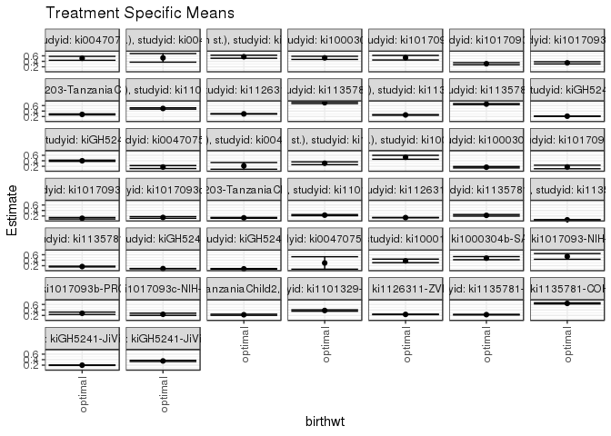

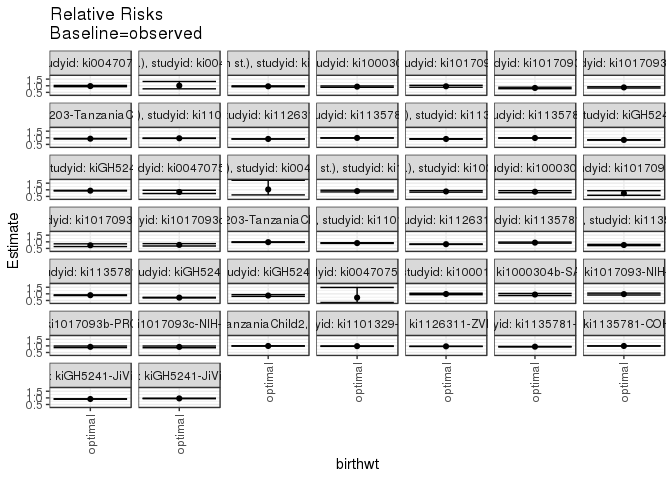

## Results Table

### Parameter: TSM

| agecat | studyid | country | intervention_level | baseline_level | estimate | ci_lower | ci_upper |
| --- | --- | --- | --- | --- | --- | --- | --- |
| 0-24 months (no birth st.) | ki0047075b-MAL-ED | BANGLADESH | optimal | NA | 0.5103140 | 0.4386885 | 0.5819395 |
| 0-24 months (no birth st.) | ki0047075b-MAL-ED | INDIA | optimal | NA | 0.5260391 | 0.3697959 | 0.6822824 |
| 0-24 months (no birth st.) | ki1000108-IRC | INDIA | optimal | NA | 0.5674859 | 0.5123028 | 0.6226690 |
| 0-24 months (no birth st.) | ki1000304b-SAS-CompFeed | INDIA | optimal | NA | 0.5260660 | 0.4690040 | 0.5831281 |
| 0-24 months (no birth st.) | ki1017093-NIH-Birth | BANGLADESH | optimal | NA | 0.5320173 | 0.4484512 | 0.6155834 |
| 0-24 months (no birth st.) | ki1017093b-PROVIDE | BANGLADESH | optimal | NA | 0.3133284 | 0.2739316 | 0.3527253 |
| 0-24 months (no birth st.) | ki1017093c-NIH-Crypto | BANGLADESH | optimal | NA | 0.3448121 | 0.3050015 | 0.3846227 |
| 0-24 months (no birth st.) | ki1066203-TanzaniaChild2 | TANZANIA, UNITED REPUBLIC OF | optimal | NA | 0.2780063 | 0.2591150 | 0.2968977 |
| 0-24 months (no birth st.) | ki1101329-Keneba | GAMBIA | optimal | NA | 0.4935598 | 0.4705426 | 0.5165770 |
| 0-24 months (no birth st.) | ki1126311-ZVITAMBO | ZIMBABWE | optimal | NA | 0.2971444 | 0.2887577 | 0.3055311 |
| 0-24 months (no birth st.) | ki1135781-COHORTS | GUATEMALA | optimal | NA | 0.7051383 | 0.6732642 | 0.7370123 |
| 0-24 months (no birth st.) | ki1135781-COHORTS | INDIA | optimal | NA | 0.2590248 | 0.2471413 | 0.2709083 |
| 0-24 months (no birth st.) | ki1135781-COHORTS | PHILIPPINES | optimal | NA | 0.6538964 | 0.6358117 | 0.6719811 |
| 0-24 months (no birth st.) | kiGH5241-JiVitA-3 | BANGLADESH | optimal | NA | 0.2125594 | 0.2046736 | 0.2204452 |
| 0-24 months (no birth st.) | kiGH5241-JiVitA-4 | BANGLADESH | optimal | NA | 0.4001434 | 0.3778222 | 0.4224646 |
| 0-6 months (no birth st.) | ki0047075b-MAL-ED | BANGLADESH | optimal | NA | 0.1716480 | 0.1175590 | 0.2257370 |
| 0-6 months (no birth st.) | ki0047075b-MAL-ED | INDIA | optimal | NA | 0.2147438 | 0.0928831 | 0.3366045 |
| 0-6 months (no birth st.) | ki1000108-IRC | INDIA | optimal | NA | 0.3092507 | 0.2577245 | 0.3607770 |
| 0-6 months (no birth st.) | ki1000109-EE | PAKISTAN | optimal | NA | 0.5266971 | 0.4552016 | 0.5981927 |
| 0-6 months (no birth st.) | ki1000304b-SAS-CompFeed | INDIA | optimal | NA | 0.1658820 | 0.1398759 | 0.1918880 |
| 0-6 months (no birth st.) | ki1017093-NIH-Birth | BANGLADESH | optimal | NA | 0.1739990 | 0.1102708 | 0.2377271 |
| 0-6 months (no birth st.) | ki1017093b-PROVIDE | BANGLADESH | optimal | NA | 0.1170192 | 0.0896419 | 0.1443966 |
| 0-6 months (no birth st.) | ki1017093c-NIH-Crypto | BANGLADESH | optimal | NA | 0.1463048 | 0.1166513 | 0.1759583 |
| 0-6 months (no birth st.) | ki1066203-TanzaniaChild2 | TANZANIA, UNITED REPUBLIC OF | optimal | NA | 0.1322724 | 0.1179928 | 0.1465521 |
| 0-6 months (no birth st.) | ki1101329-Keneba | GAMBIA | optimal | NA | 0.2304732 | 0.2105131 | 0.2504333 |
| 0-6 months (no birth st.) | ki1126311-ZVITAMBO | ZIMBABWE | optimal | NA | 0.1402725 | 0.1338927 | 0.1466522 |
| 0-6 months (no birth st.) | ki1135781-COHORTS | GUATEMALA | optimal | NA | 0.2232140 | 0.1937740 | 0.2526541 |
| 0-6 months (no birth st.) | ki1135781-COHORTS | INDIA | optimal | NA | 0.0597453 | 0.0532246 | 0.0662661 |
| 0-6 months (no birth st.) | ki1135781-COHORTS | PHILIPPINES | optimal | NA | 0.1693876 | 0.1551010 | 0.1836741 |
| 0-6 months (no birth st.) | kiGH5241-JiVitA-3 | BANGLADESH | optimal | NA | 0.0938866 | 0.0884520 | 0.0993212 |
| 0-6 months (no birth st.) | kiGH5241-JiVitA-4 | BANGLADESH | optimal | NA | 0.0852607 | 0.0730922 | 0.0974292 |
| 6-24 months | ki0047075b-MAL-ED | INDIA | optimal | NA | 0.2993190 | 0.0713737 | 0.5272642 |
| 6-24 months | ki1000108-IRC | INDIA | optimal | NA | 0.3745725 | 0.3096117 | 0.4395332 |
| 6-24 months | ki1000304b-SAS-CompFeed | INDIA | optimal | NA | 0.4745665 | 0.4179974 | 0.5311355 |
| 6-24 months | ki1017093-NIH-Birth | BANGLADESH | optimal | NA | 0.5379961 | 0.4350838 | 0.6409083 |
| 6-24 months | ki1017093b-PROVIDE | BANGLADESH | optimal | NA | 0.2779550 | 0.2340846 | 0.3218254 |
| 6-24 months | ki1017093c-NIH-Crypto | BANGLADESH | optimal | NA | 0.2417029 | 0.2017471 | 0.2816587 |
| 6-24 months | ki1066203-TanzaniaChild2 | TANZANIA, UNITED REPUBLIC OF | optimal | NA | 0.2247348 | 0.2040291 | 0.2454404 |
| 6-24 months | ki1101329-Keneba | GAMBIA | optimal | NA | 0.3799180 | 0.3543867 | 0.4054493 |
| 6-24 months | ki1126311-ZVITAMBO | ZIMBABWE | optimal | NA | 0.2374846 | 0.2278731 | 0.2470962 |
| 6-24 months | ki1135781-COHORTS | INDIA | optimal | NA | 0.2289802 | 0.2168105 | 0.2411498 |
| 6-24 months | ki1135781-COHORTS | PHILIPPINES | optimal | NA | 0.6381332 | 0.6171401 | 0.6591263 |
| 6-24 months | kiGH5241-JiVitA-3 | BANGLADESH | optimal | NA | 0.1984240 | 0.1889648 | 0.2078833 |
| 6-24 months | kiGH5241-JiVitA-4 | BANGLADESH | optimal | NA | 0.3527990 | 0.3310054 | 0.3745927 |

### Parameter: E(Y)

| agecat | studyid | country | intervention_level | baseline_level | estimate | ci_lower | ci_upper |
| --- | --- | --- | --- | --- | --- | --- | --- |
| 0-24 months (no birth st.) | ki0047075b-MAL-ED | BANGLADESH | observed | NA | 0.5232318 | 0.4558421 | 0.5906214 |
| 0-24 months (no birth st.) | ki0047075b-MAL-ED | INDIA | observed | NA | 0.5218827 | 0.4533364 | 0.5904290 |
| 0-24 months (no birth st.) | ki1000108-IRC | INDIA | observed | NA | 0.5918635 | 0.5408864 | 0.6428406 |
| 0-24 months (no birth st.) | ki1000304b-SAS-CompFeed | INDIA | observed | NA | 0.5636284 | 0.5051431 | 0.6221137 |
| 0-24 months (no birth st.) | ki1017093-NIH-Birth | BANGLADESH | observed | NA | 0.5547950 | 0.4823947 | 0.6271953 |
| 0-24 months (no birth st.) | ki1017093b-PROVIDE | BANGLADESH | observed | NA | 0.3758797 | 0.3381579 | 0.4136016 |
| 0-24 months (no birth st.) | ki1017093c-NIH-Crypto | BANGLADESH | observed | NA | 0.3942670 | 0.3567675 | 0.4317665 |
| 0-24 months (no birth st.) | ki1066203-TanzaniaChild2 | TANZANIA, UNITED REPUBLIC OF | observed | NA | 0.2987929 | 0.2797146 | 0.3178713 |
| 0-24 months (no birth st.) | ki1101329-Keneba | GAMBIA | observed | NA | 0.5126512 | 0.4903344 | 0.5349679 |
| 0-24 months (no birth st.) | ki1126311-ZVITAMBO | ZIMBABWE | observed | NA | 0.3259539 | 0.3177532 | 0.3341545 |
| 0-24 months (no birth st.) | ki1135781-COHORTS | GUATEMALA | observed | NA | 0.7142488 | 0.6835524 | 0.7449453 |
| 0-24 months (no birth st.) | ki1135781-COHORTS | INDIA | observed | NA | 0.2849018 | 0.2734401 | 0.2963634 |
| 0-24 months (no birth st.) | ki1135781-COHORTS | PHILIPPINES | observed | NA | 0.6647605 | 0.6473636 | 0.6821574 |
| 0-24 months (no birth st.) | kiGH5241-JiVitA-3 | BANGLADESH | observed | NA | 0.2540181 | 0.2461911 | 0.2618451 |
| 0-24 months (no birth st.) | kiGH5241-JiVitA-4 | BANGLADESH | observed | NA | 0.4285839 | 0.4080994 | 0.4490684 |
| 0-6 months (no birth st.) | ki0047075b-MAL-ED | BANGLADESH | observed | NA | 0.2062543 | 0.1515335 | 0.2609750 |
| 0-6 months (no birth st.) | ki0047075b-MAL-ED | INDIA | observed | NA | 0.2091253 | 0.1532563 | 0.2649943 |
| 0-6 months (no birth st.) | ki1000108-IRC | INDIA | observed | NA | 0.3426327 | 0.2933701 | 0.3918953 |
| 0-6 months (no birth st.) | ki1000109-EE | PAKISTAN | observed | NA | 0.6011844 | 0.5402747 | 0.6620940 |
| 0-6 months (no birth st.) | ki1000304b-SAS-CompFeed | INDIA | observed | NA | 0.1942921 | 0.1699021 | 0.2186821 |
| 0-6 months (no birth st.) | ki1017093-NIH-Birth | BANGLADESH | observed | NA | 0.2353287 | 0.1734446 | 0.2972128 |
| 0-6 months (no birth st.) | ki1017093b-PROVIDE | BANGLADESH | observed | NA | 0.1587583 | 0.1302494 | 0.1872673 |
| 0-6 months (no birth st.) | ki1017093c-NIH-Crypto | BANGLADESH | observed | NA | 0.1904187 | 0.1603129 | 0.2205245 |
| 0-6 months (no birth st.) | ki1066203-TanzaniaChild2 | TANZANIA, UNITED REPUBLIC OF | observed | NA | 0.1357469 | 0.1214694 | 0.1500245 |
| 0-6 months (no birth st.) | ki1101329-Keneba | GAMBIA | observed | NA | 0.2548462 | 0.2348359 | 0.2748565 |
| 0-6 months (no birth st.) | ki1126311-ZVITAMBO | ZIMBABWE | observed | NA | 0.1709151 | 0.1643252 | 0.1775050 |
| 0-6 months (no birth st.) | ki1135781-COHORTS | GUATEMALA | observed | NA | 0.2378633 | 0.2086283 | 0.2670983 |
| 0-6 months (no birth st.) | ki1135781-COHORTS | INDIA | observed | NA | 0.0786940 | 0.0717857 | 0.0856022 |
| 0-6 months (no birth st.) | ki1135781-COHORTS | PHILIPPINES | observed | NA | 0.1886765 | 0.1742586 | 0.2030944 |
| 0-6 months (no birth st.) | kiGH5241-JiVitA-3 | BANGLADESH | observed | NA | 0.1314780 | 0.1258407 | 0.1371154 |
| 0-6 months (no birth st.) | kiGH5241-JiVitA-4 | BANGLADESH | observed | NA | 0.0978413 | 0.0851010 | 0.1105815 |
| 6-24 months | ki0047075b-MAL-ED | INDIA | observed | NA | 0.4181998 | 0.3397810 | 0.4966185 |
| 6-24 months | ki1000108-IRC | INDIA | observed | NA | 0.3789233 | 0.3167730 | 0.4410737 |
| 6-24 months | ki1000304b-SAS-CompFeed | INDIA | observed | NA | 0.5011297 | 0.4563200 | 0.5459394 |
| 6-24 months | ki1017093-NIH-Birth | BANGLADESH | observed | NA | 0.5489491 | 0.4537391 | 0.6441590 |
| 6-24 months | ki1017093b-PROVIDE | BANGLADESH | observed | NA | 0.3000581 | 0.2580063 | 0.3421099 |
| 6-24 months | ki1017093c-NIH-Crypto | BANGLADESH | observed | NA | 0.2624443 | 0.2240531 | 0.3008355 |
| 6-24 months | ki1066203-TanzaniaChild2 | TANZANIA, UNITED REPUBLIC OF | observed | NA | 0.2265620 | 0.2059734 | 0.2471506 |
| 6-24 months | ki1101329-Keneba | GAMBIA | observed | NA | 0.3881371 | 0.3630436 | 0.4132307 |
| 6-24 months | ki1126311-ZVITAMBO | ZIMBABWE | observed | NA | 0.2466508 | 0.2371679 | 0.2561337 |
| 6-24 months | ki1135781-COHORTS | INDIA | observed | NA | 0.2439862 | 0.2322512 | 0.2557213 |
| 6-24 months | ki1135781-COHORTS | PHILIPPINES | observed | NA | 0.6436007 | 0.6230772 | 0.6641242 |
| 6-24 months | kiGH5241-JiVitA-3 | BANGLADESH | observed | NA | 0.2166021 | 0.2071769 | 0.2260273 |
| 6-24 months | kiGH5241-JiVitA-4 | BANGLADESH | observed | NA | 0.3676583 | 0.3467883 | 0.3885282 |

### Parameter: RR

| agecat | studyid | country | intervention_level | baseline_level | estimate | ci_lower | ci_upper |
| --- | --- | --- | --- | --- | --- | --- | --- |
| 0-24 months (no birth st.) | ki0047075b-MAL-ED | BANGLADESH | optimal | observed | 0.9753116 | 0.9305036 | 1.0222772 |
| 0-24 months (no birth st.) | ki0047075b-MAL-ED | INDIA | optimal | observed | 1.0079644 | 0.7689405 | 1.3212884 |
| 0-24 months (no birth st.) | ki1000108-IRC | INDIA | optimal | observed | 0.9588122 | 0.9269293 | 0.9917917 |
| 0-24 months (no birth st.) | ki1000304b-SAS-CompFeed | INDIA | optimal | observed | 0.9333561 | 0.8851702 | 0.9841651 |
| 0-24 months (no birth st.) | ki1017093-NIH-Birth | BANGLADESH | optimal | observed | 0.9589439 | 0.8881207 | 1.0354150 |
| 0-24 months (no birth st.) | ki1017093b-PROVIDE | BANGLADESH | optimal | observed | 0.8335870 | 0.7809370 | 0.8897865 |
| 0-24 months (no birth st.) | ki1017093c-NIH-Crypto | BANGLADESH | optimal | observed | 0.8745650 | 0.8281395 | 0.9235931 |
| 0-24 months (no birth st.) | ki1066203-TanzaniaChild2 | TANZANIA, UNITED REPUBLIC OF | optimal | observed | 0.9304315 | 0.9105726 | 0.9507234 |
| 0-24 months (no birth st.) | ki1101329-Keneba | GAMBIA | optimal | observed | 0.9627595 | 0.9511001 | 0.9745619 |
| 0-24 months (no birth st.) | ki1126311-ZVITAMBO | ZIMBABWE | optimal | observed | 0.9116149 | 0.9020856 | 0.9212448 |
| 0-24 months (no birth st.) | ki1135781-COHORTS | GUATEMALA | optimal | observed | 0.9872446 | 0.9785251 | 0.9960417 |
| 0-24 months (no birth st.) | ki1135781-COHORTS | INDIA | optimal | observed | 0.9091723 | 0.8916211 | 0.9270689 |
| 0-24 months (no birth st.) | ki1135781-COHORTS | PHILIPPINES | optimal | observed | 0.9836571 | 0.9774388 | 0.9899150 |
| 0-24 months (no birth st.) | kiGH5241-JiVitA-3 | BANGLADESH | optimal | observed | 0.8367885 | 0.8223844 | 0.8514448 |
| 0-24 months (no birth st.) | kiGH5241-JiVitA-4 | BANGLADESH | optimal | observed | 0.9336408 | 0.9117009 | 0.9561088 |
| 0-6 months (no birth st.) | ki0047075b-MAL-ED | BANGLADESH | optimal | observed | 0.8322157 | 0.7184242 | 0.9640305 |
| 0-6 months (no birth st.) | ki0047075b-MAL-ED | INDIA | optimal | observed | 1.0268666 | 0.6134355 | 1.7189337 |
| 0-6 months (no birth st.) | ki1000108-IRC | INDIA | optimal | observed | 0.9025722 | 0.8408749 | 0.9687963 |
| 0-6 months (no birth st.) | ki1000109-EE | PAKISTAN | optimal | observed | 0.8760992 | 0.8200459 | 0.9359838 |
| 0-6 months (no birth st.) | ki1000304b-SAS-CompFeed | INDIA | optimal | observed | 0.8537761 | 0.7812976 | 0.9329783 |
| 0-6 months (no birth st.) | ki1017093-NIH-Birth | BANGLADESH | optimal | observed | 0.7393870 | 0.5864681 | 0.9321789 |
| 0-6 months (no birth st.) | ki1017093b-PROVIDE | BANGLADESH | optimal | observed | 0.7370904 | 0.6406597 | 0.8480357 |
| 0-6 months (no birth st.) | ki1017093c-NIH-Crypto | BANGLADESH | optimal | observed | 0.7683320 | 0.6842494 | 0.8627469 |
| 0-6 months (no birth st.) | ki1066203-TanzaniaChild2 | TANZANIA, UNITED REPUBLIC OF | optimal | observed | 0.9744047 | 0.9527042 | 0.9965995 |
| 0-6 months (no birth st.) | ki1101329-Keneba | GAMBIA | optimal | observed | 0.9043620 | 0.8769521 | 0.9326286 |
| 0-6 months (no birth st.) | ki1126311-ZVITAMBO | ZIMBABWE | optimal | observed | 0.8207143 | 0.8030847 | 0.8387309 |
| 0-6 months (no birth st.) | ki1135781-COHORTS | GUATEMALA | optimal | observed | 0.9384132 | 0.9005739 | 0.9778422 |
| 0-6 months (no birth st.) | ki1135781-COHORTS | INDIA | optimal | observed | 0.7592113 | 0.7134621 | 0.8078939 |
| 0-6 months (no birth st.) | ki1135781-COHORTS | PHILIPPINES | optimal | observed | 0.8977671 | 0.8699850 | 0.9264363 |
| 0-6 months (no birth st.) | kiGH5241-JiVitA-3 | BANGLADESH | optimal | observed | 0.7140857 | 0.6899197 | 0.7390981 |
| 0-6 months (no birth st.) | kiGH5241-JiVitA-4 | BANGLADESH | optimal | observed | 0.8714189 | 0.8077809 | 0.9400703 |
| 6-24 months | ki0047075b-MAL-ED | INDIA | optimal | observed | 0.7157320 | 0.3458599 | 1.4811552 |
| 6-24 months | ki1000108-IRC | INDIA | optimal | observed | 0.9885178 | 0.9373151 | 1.0425176 |
| 6-24 months | ki1000304b-SAS-CompFeed | INDIA | optimal | observed | 0.9469934 | 0.8718458 | 1.0286182 |
| 6-24 months | ki1017093-NIH-Birth | BANGLADESH | optimal | observed | 0.9800473 | 0.9124924 | 1.0526035 |
| 6-24 months | ki1017093b-PROVIDE | BANGLADESH | optimal | observed | 0.9263374 | 0.8688747 | 0.9876003 |
| 6-24 months | ki1017093c-NIH-Crypto | BANGLADESH | optimal | observed | 0.9209684 | 0.8594366 | 0.9869057 |
| 6-24 months | ki1066203-TanzaniaChild2 | TANZANIA, UNITED REPUBLIC OF | optimal | observed | 0.9919350 | 0.9782673 | 1.0057937 |
| 6-24 months | ki1101329-Keneba | GAMBIA | optimal | observed | 0.9788242 | 0.9644399 | 0.9934231 |
| 6-24 months | ki1126311-ZVITAMBO | ZIMBABWE | optimal | observed | 0.9628376 | 0.9521459 | 0.9736493 |
| 6-24 months | ki1135781-COHORTS | INDIA | optimal | observed | 0.9384962 | 0.9192982 | 0.9580951 |
| 6-24 months | ki1135781-COHORTS | PHILIPPINES | optimal | observed | 0.9915049 | 0.9857467 | 0.9972967 |
| 6-24 months | kiGH5241-JiVitA-3 | BANGLADESH | optimal | observed | 0.9160764 | 0.8984496 | 0.9340490 |
| 6-24 months | kiGH5241-JiVitA-4 | BANGLADESH | optimal | observed | 0.9595841 | 0.9396632 | 0.9799273 |